# Inferência via ICs

Js Lucas

21 de maio de 2018

## Introdução

A [Wikimedia Foundation](https://wikimediafoundation.org/wiki/Home) é uma organização sem fins lucrativos que mantém projetos baseados em [wiki](https://en.wikipedia.org/wiki/Wiki) como a Wikipedia.

Neste relatório, iremos responder algumas perguntas propostas por eles, em um [desafio para seleção de analistas de dados](https://github.com/wikimedia-research/Discovery-Hiring-Analyst-2016):

1. Qual é nossa taxa de click geral diária? Como ela varia entre os grupos?
2. Qual resultados as pessoas tendem a tentar primeiro? Como ela muda dia a dia?
3. Qual é nossa taxa de resultados zerados diária? Como ela varia entre os grupos?

Para responder essas perguntas, utilizaremos os [dados](https://github.com/wikimedia-research/Discovery-Hiring-Analyst-2016/raw/master/events_log.csv.gz) fornecidos por eles e modificados pelo professor Nazareno Andrade Como os dados providos pela Wikimedia são apenas uma amostra, utilizaremos bootstrap e intervalo de confiança para inferir sobre a amostra. Nossas análises serão baseadas em um nível de 95% de confiança.

```r
library(here)
library(boot)
library(lubridate)
library(dplyr)
```

```r
library(readr)
library(ggplot2)

buscas <- read_csv(here::here("data/search_data.csv"))
buscas <- buscas %>%
    filter(!(num_clicks > results & results == 0))
```

## Definições

Antes de mais nada, é importante para responder as perguntas a seguir, definir dois conceitos.

Taxa de cliques: A proporção de sessões em que o usuário clicou em ao menos um dos resultados. Taxa de resultados zerados: A proporção de sessões com 0 resultados.

## **Qual é nossa taxa de click geral diária? Como ela varia entre os grupos?**

Vamos utilizar inferência para calcular a taxa diária.

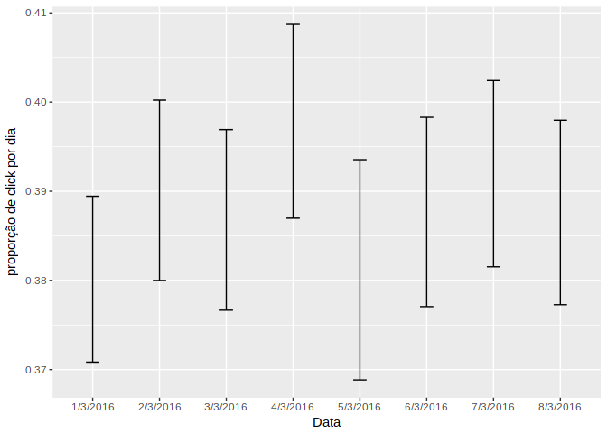

```r
sessoes <- buscas %>%
    group_by(session_id) %>%
    summarise(grupo = first(group),
              com_clique = sum(num_clicks, na.rm = TRUE) > 0,
              data = paste(day(first(session_start_date)), month(first(session_start_date)), year(first(session_start_date)), sep = "/"))

taxa_de_cliques <- function(value, i){
    return(sum(value[i])/length(value))
}

cliques_por_dia <- sessoes %>%
    group_by(data) %>%
    summarise(boot = list(boot(com_clique, taxa_de_cliques, R = 1000)),
              ci = list(boot.ci(boot[[1]], conf = 0.95, type = "basic")),
              lim_inf = ci[[1]][[4]][4],
              lim_sup = ci[[1]][[4]][5]) %>%
    select(-c(boot, ci))

cliques_por_dia %>%
    ggplot(aes(x = data, ymin = lim_inf, ymax = lim_sup)) +
    geom_errorbar(width = .2) +
    labs(x = "Data", y = "proporção de click por dia")
```

Podemos observar, em geral a taxa diária de cliques é baixa. Assumindo com 95% de confiança, valores entre 0.36 e 0.40. Aparentemente existe pouca diferença entre os dias, uma vez que todos apresentam intervalos muito próximos, entretanto, há diferença entre os grupos?

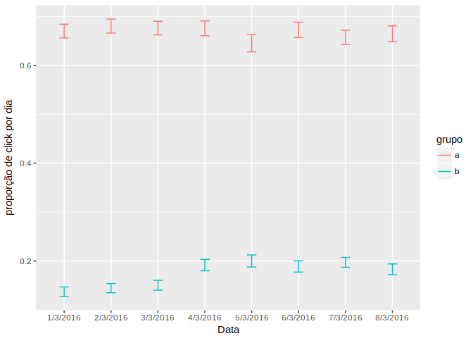

```r
cliques_por_dia_grupos <- sessoes %>%
    group_by(data, grupo) %>%
    summarise(boot = list(boot(com_clique, taxa_de_cliques, R = 1000)),
              ci = list(boot.ci(boot[[1]], conf = 0.95, type = "basic")),
              lim_inf = ci[[1]][[4]][4],
              lim_sup = ci[[1]][[4]][5]) %>%
    select(-c(boot, ci))

cliques_por_dia_grupos %>%
    ggplot(aes(x = data, ymin = lim_inf, ymax = lim_sup, color = grupo)) +
    geom_errorbar(width = .2) +
    labs(x = "Data", y = "proporção de click por dia")
```

A resposta é sim. As sessões do grupo B apresentaram intervalos com valores muito abaixo daquelas do grupo A. Para este, a maioria das sessões resulta em clique com 95% de confiança, uma vez que todos seus intervalos estão acima de 0.5. Já as sessões do grupo B possuem resultados ainda mais baixos, variando entre 0.1 e 0.2.